# Tests for quality and performance

Both GRIA and TeitzBart are tested on the following topics:

- Performance
- Solution quality

The motivation for the first part is self-evident. The “quality” of the solution demands some explanation. It is tested due to the fact that neither algorithm is guaranteed to provide an optimal solution. However, both are said to provide “good results”. The quality is tested by calculating the difference in cost to an optimal solution.

(See [this article](https://link.springer.com/article/10.1007/BF01434270) for description of the problem and algorithms)

#### **Test info**

All algorithms were tested on the same data that consisted of a varying number of possible facility locations and demand locations.

The coordinates of locations are random double numbers ranging from 1 to 200. These were created with [Java’s Random-class](https://docs.oracle.com/javase/8/docs/api/java/util/Random.html).

### **1. Smaller tests: Brute force vs. GRIA vs. TeitzBart**

- Possible facility locations: 25
- Demand locations: 300 .
- Tests run 10 times and results averaged.

The brute force algorithm is guaranteed to produce optimal results, but it comes with a cost. If P 12 is, GRIA is faster than the brute force solution by a factor of 15910.33.

##### Runtime of solutions (in milliseconds)

| P | Combinations | BruteForce | TeitzBart | GRIA |
| --- | --- | --- | --- | --- |
| 2 | 300 | 24.1 | 0.3 | 0.3 |
| 3 | 2300 | 26.8 | 0.8 | 0.8 |
| 4 | 12650 | 76.6 | 0.7 | 0.7 |
| 5 | 53130 | 322.6 | 1.4 | 1.4 |
| 6 | 177100 | 1064.4 | 1.2 | 1.2 |
| 7 | 480700 | 3299.8 | 1.8 | 1.8 |
| 8 | 1081575 | 7574.6 | 2.1 | 2.1 |
| 9 | 2042975 | 14749.9 | 2.3 | 2.3 |
| 10 | 3268760 | 24212.7 | 2.6 | 2.6 |
| 11 | 4457400 | 35701.7 | 2.5 | 2.5 |
| 12 | 5200300 | 42957.9 | 2.7 | 2.7 |

GRIA and TeitzBart do not necessarily produce optimal results, but they’re not far off. The average error of GRIA is 142.1 which is 1.36% of the average optimal solution. By “error” I mean difference between the optimal solution and GRIA’s/TeitzBar’s solution.

##### Costs (sum of distances of solution)

| P | BruteForce | TeitzBart | TeitzBartError | GRIA | GRIAerror |
| --- | --- | --- | --- | --- | --- |
| 2 | 17641.0 | 17929.3 | 288.3 | 17852.5 | 211.5 |
| 3 | 14273.9 | 14372.2 | 98.3 | 14430.6 | 156.7 |
| 4 | 12256.6 | 12367.6 | 111.0 | 12678.5 | 421.8 |
| 5 | 10844.6 | 11030.8 | 186.2 | 10996.6 | 152.0 |
| 6 | 10030.3 | 10250.5 | 220.2 | 10221.9 | 191.7 |
| 7 | 9283.9 | 9355.2 | 71.3 | 9359.9 | 76.1 |
| 8 | 8607.3 | 8724.1 | 116.9 | 8709.4 | 102.1 |
| 9 | 8373.0 | 8431.0 | 58.0 | 8469.1 | 96.0 |
| 10 | 8042.5 | 8135.3 | 92.8 | 8134.9 | 92.4 |
| 11 | 7878.8 | 7902.6 | 23.8 | 7916.8 | 38.0 |
| 12 | 7377.2 | 7415.5 | 38.3 | 7402.2 | 25.0 |
| Mean | 10419.0 | 10537.6 | 118.6 | 10561.1 | 142.1 |

### **2. Bigger tests: GRIA vs. TeitzBart**

- Possible facility locations: 50.
- Demand locations: 300.
- Tests run 100 times and results averaged.

#### **Performance: Runtime vs. P (number of possible facility locations)**

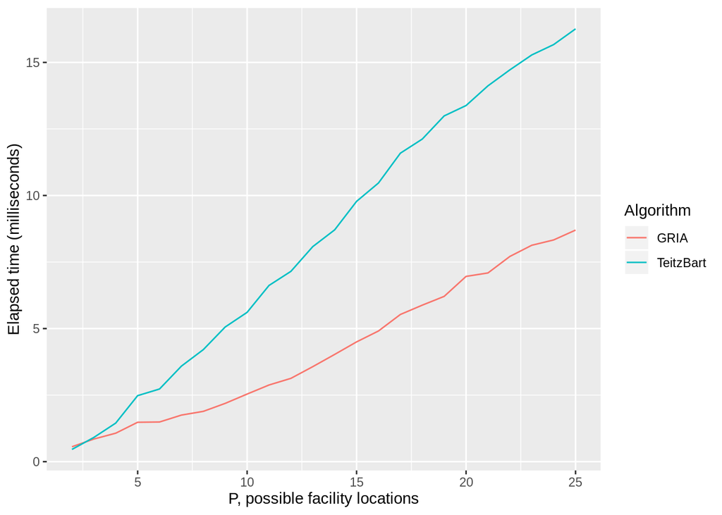

#### **Cost of solution**

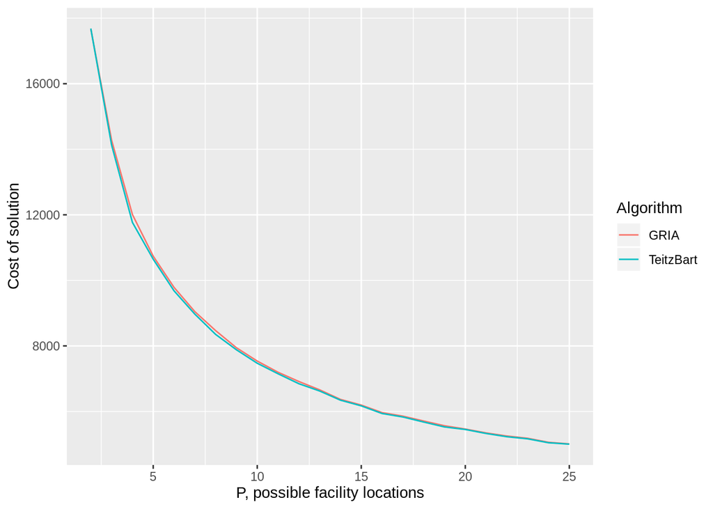